# Case Study 1

```python
import pandas as pd
import numpy as np
import matplotlib.pyplot as plt
import seaborn as sns

from sklearn.preprocessing import RobustScaler
from sklearn.preprocessing import LabelEncoder

import statsmodels.api as sm
import statsmodels.formula.api as smf
from statsmodels.stats.outliers_influence import variance_inflation_factor
%matplotlib inline

import warnings
warnings.filterwarnings("ignore")
```

```python
loan_df = pd.read_csv("loans_full_schema.csv")
```

```python
loan_df.head()
```

|  | emp_title | emp_length | state | homeownership | annual_income | verified_income | debt_to_income | annual_income_joint | verification_income_joint | debt_to_income_joint | ... | sub_grade | issue_month | loan_status | initial_listing_status | disbursement_method | balance | paid_total | paid_principal | paid_interest | paid_late_fees |
| --- | --- | --- | --- | --- | --- | --- | --- | --- | --- | --- | --- | --- | --- | --- | --- | --- | --- | --- | --- | --- | --- |
| 0 | global config engineer | 3.0 | NJ | MORTGAGE | 90000.0 | Verified | 18.01 | NaN | NaN | NaN | ... | C3 | Mar-2018 | Current | whole | Cash | 27015.86 | 1999.33 | 984.14 | 1015.19 | 0.0 |
| 1 | warehouse office clerk | 10.0 | HI | RENT | 40000.0 | Not Verified | 5.04 | NaN | NaN | NaN | ... | C1 | Feb-2018 | Current | whole | Cash | 4651.37 | 499.12 | 348.63 | 150.49 | 0.0 |
| 2 | assembly | 3.0 | WI | RENT | 40000.0 | Source Verified | 21.15 | NaN | NaN | NaN | ... | D1 | Feb-2018 | Current | fractional | Cash | 1824.63 | 281.80 | 175.37 | 106.43 | 0.0 |
| 3 | customer service | 1.0 | PA | RENT | 30000.0 | Not Verified | 10.16 | NaN | NaN | NaN | ... | A3 | Jan-2018 | Current | whole | Cash | 18853.26 | 3312.89 | 2746.74 | 566.15 | 0.0 |
| 4 | security supervisor | 10.0 | CA | RENT | 35000.0 | Verified | 57.96 | 57000.0 | Verified | 37.66 | ... | C3 | Mar-2018 | Current | whole | Cash | 21430.15 | 2324.65 | 1569.85 | 754.80 | 0.0 |

5 rows × 55 columns

```python
loan_df.describe()
```

|  | emp_length | annual_income | debt_to_income | annual_income_joint | debt_to_income_joint | delinq_2y | months_since_last_delinq | earliest_credit_line | inquiries_last_12m | total_credit_lines | ... | public_record_bankrupt | loan_amount | term | interest_rate | installment | balance | paid_total | paid_principal | paid_interest | paid_late_fees |
| --- | --- | --- | --- | --- | --- | --- | --- | --- | --- | --- | --- | --- | --- | --- | --- | --- | --- | --- | --- | --- | --- |
| count | 9183.000000 | 1.000000e+04 | 9976.000000 | 1.495000e+03 | 1495.000000 | 10000.00000 | 4342.000000 | 10000.00000 | 10000.00000 | 10000.000000 | ... | 10000.000000 | 10000.000000 | 10000.000000 | 10000.000000 | 10000.000000 | 10000.000000 | 10000.000000 | 10000.000000 | 10000.000000 | 10000.000000 |
| mean | 5.930306 | 7.922215e+04 | 19.308192 | 1.279146e+05 | 19.979304 | 0.21600 | 36.760709 | 2001.29000 | 1.95820 | 22.679600 | ... | 0.123800 | 16361.922500 | 43.272000 | 12.427524 | 476.205323 | 14458.916610 | 2494.234773 | 1894.448466 | 599.666781 | 0.119516 |
| std | 3.703734 | 6.473429e+04 | 15.004851 | 7.016838e+04 | 8.054781 | 0.68366 | 21.634939 | 7.79551 | 2.38013 | 11.885439 | ... | 0.337172 | 10301.956759 | 11.029877 | 5.001105 | 294.851627 | 9964.561865 | 3958.230365 | 3884.407175 | 517.328062 | 1.813468 |
| min | 0.000000 | 0.000000e+00 | 0.000000 | 1.920000e+04 | 0.320000 | 0.00000 | 1.000000 | 1963.00000 | 0.00000 | 2.000000 | ... | 0.000000 | 1000.000000 | 36.000000 | 5.310000 | 30.750000 | 0.000000 | 0.000000 | 0.000000 | 0.000000 | 0.000000 |
| 25% | 2.000000 | 4.500000e+04 | 11.057500 | 8.683350e+04 | 14.160000 | 0.00000 | 19.000000 | 1997.00000 | 0.00000 | 14.000000 | ... | 0.000000 | 8000.000000 | 36.000000 | 9.430000 | 256.040000 | 6679.065000 | 928.700000 | 587.100000 | 221.757500 | 0.000000 |
| 50% | 6.000000 | 6.500000e+04 | 17.570000 | 1.130000e+05 | 19.720000 | 0.00000 | 34.000000 | 2003.00000 | 1.00000 | 21.000000 | ... | 0.000000 | 14500.000000 | 36.000000 | 11.980000 | 398.420000 | 12379.495000 | 1563.300000 | 984.990000 | 446.140000 | 0.000000 |
| 75% | 10.000000 | 9.500000e+04 | 25.002500 | 1.515455e+05 | 25.500000 | 0.00000 | 53.000000 | 2006.00000 | 3.00000 | 29.000000 | ... | 0.000000 | 24000.000000 | 60.000000 | 15.050000 | 644.690000 | 20690.182500 | 2616.005000 | 1694.555000 | 825.420000 | 0.000000 |
| max | 10.000000 | 2.300000e+06 | 469.090000 | 1.100000e+06 | 39.980000 | 13.00000 | 118.000000 | 2015.00000 | 29.00000 | 87.000000 | ... | 3.000000 | 40000.000000 | 60.000000 | 30.940000 | 1566.590000 | 40000.000000 | 41630.443684 | 40000.000000 | 4216.440000 | 52.980000 |

8 rows × 42 columns

## Data Description:

### This data has 55 columns and 10,000 contining the credit and demographic information of its customers. There are 10 columns with null values from ranging 24 to 8500.

### This dataset also 13 'object' columns which are categorical along with a few other categorical columns that I describe below. The problem that we have to deal with here is to deal with the null values.

# Data Exploration

```python
loan_df.info()
```

```
<class 'pandas.core.frame.DataFrame'>
RangeIndex: 10000 entries, 0 to 9999
Data columns (total 55 columns):
 #   Column                            Non-Null Count  Dtype
---  ------                            --------------  -----
 0   emp_title                         9167 non-null   object
 1   emp_length                        9183 non-null   float64
 2   state                             10000 non-null  object
 3   homeownership                     10000 non-null  object
 4   annual_income                     10000 non-null  float64
 5   verified_income                   10000 non-null  object
 6   debt_to_income                    9976 non-null   float64
 7   annual_income_joint               1495 non-null   float64
 8   verification_income_joint         1455 non-null   object
 9   debt_to_income_joint              1495 non-null   float64
```

[output cut: 47 more lines]

```python
loan_df.isnull().sum()
```

```
emp_title                            833
emp_length                           817
state                                  0
homeownership                          0
annual_income                          0
verified_income                        0
debt_to_income                        24
annual_income_joint                 8505
verification_income_joint           8545
debt_to_income_joint                8505
delinq_2y                              0
months_since_last_delinq            5658
earliest_credit_line                   0
inquiries_last_12m                     0
total_credit_lines                     0
open_credit_lines                      0
total_credit_limit                     0
total_credit_utilized                  0
num_collections_last_12m               0
num_historical_failed_to_pay           0
months_since_90d_late               7715
current_accounts_delinq                0
total_collection_amount_ever           0
current_installment_accounts           0
accounts_opened_24m                    0
months_since_last_credit_inquiry    1271
num_satisfactory_accounts              0
num_accounts_120d_past_due           318
num_accounts_30d_past_due              0
num_active_debit_accounts              0
total_debit_limit                      0
num_total_cc_accounts                  0
num_open_cc_accounts                   0
num_cc_carrying_balance                0
num_mort_accounts                      0
account_never_delinq_percent           0
tax_liens                              0
public_record_bankrupt                 0
loan_purpose                           0
application_type                       0
loan_amount                            0
term                                   0
interest_rate                          0
installment                            0
grade                                  0
sub_grade                              0
issue_month                            0
loan_status                            0
initial_listing_status                 0
disbursement_method                    0
balance                                0
paid_total                             0
paid_principal                         0
paid_interest                          0
paid_late_fees                         0
dtype: int64
```

#### Checking Categorical columns

```python
loan_df.dtypes.value_counts()
```

```
int64      25
float64    17
object     13
dtype: int64
```

```python
loan_df.shape
```

```
(10000, 55)
```

```python
loan_df.loan_status.unique()
```

```
array(['Current', 'Fully Paid', 'In Grace Period', 'Late (31-120 days)',
       'Charged Off', 'Late (16-30 days)'], dtype=object)
```

```python
loan_df.months_since_last_delinq .unique()
```

```
array([ 38.,  nan,  28.,   3.,  19.,  18.,  50.,  37.,  44.,   6.,  77.,
        14.,  67.,  70.,  68.,  35.,  31., 102.,  80.,  61.,  26.,   7.,
        49.,  43.,  15.,  75.,  27.,  34.,  56.,  36.,  48.,  58.,  59.,
         5.,  62.,  22.,  47.,  78.,  10.,  53.,  24.,  39.,  45.,  12.,
        32.,  25.,  29.,  55.,  63.,  81.,  16.,  21.,  33.,  79.,  60.,
        82.,  69.,   4.,  66.,  52.,  20.,  30.,  41.,  57.,  64.,  11.,
         1.,  71.,  23.,  13.,   8.,  72.,  17.,  51.,  74.,   9.,  46.,
        54.,  65.,  42.,  83.,  76.,  73.,  99.,  40.,  84.,   2.,  91.,
       101.,  89.,  87., 100.,  96., 109.,  88., 118., 106.,  98.])
```

```python
loan_df.initial_listing_status.unique()
```

```
array(['whole', 'fractional'], dtype=object)
```

```python
loan_df.disbursement_method.unique()
```

```
array(['Cash', 'DirectPay'], dtype=object)
```

```python
loan_df.loan_purpose.unique()
```

```
array(['moving', 'debt_consolidation', 'other', 'credit_card',
       'home_improvement', 'medical', 'house', 'small_business', 'car',
       'major_purchase', 'vacation', 'renewable_energy'], dtype=object)
```

```python
loan_df.application_type.unique()
```

```
array(['individual', 'joint'], dtype=object)
```

```python
loan_df.emp_title.unique()
```

```
array(['global config engineer ', 'warehouse office clerk', 'assembly',
       ..., 'inspector/packer', 'da coordinator ', 'toolmaker'],
      dtype=object)
```

```python
loan_df['emp_title'].value_counts()
```

```
manager                     218
owner                       204
teacher                     201
driver                      123
sales                        97
                           ...
corporate tax director        1
captain-fire department       1
intervention specialist       1
coffee roaster                1
toolmaker                     1
Name: emp_title, Length: 4741, dtype: int64
```

```python
loan_df.issue_month.unique()
```

```
array(['Mar-2018', 'Feb-2018', 'Jan-2018'], dtype=object)
```

```python
loan_df.delinq_2y .unique()
```

```
array([ 0,  1,  3,  4,  7,  2,  8,  6, 10,  5,  9, 13])
```

```python
loan_df.homeownership.unique()
```

```
array(['MORTGAGE', 'RENT', 'OWN'], dtype=object)
```

```python
loan_df['loan_status'].value_counts()
```

```
Current               9375
Fully Paid             447
In Grace Period         67
Late (31-120 days)      66
Late (16-30 days)       38
Charged Off              7
Name: loan_status, dtype: int64
```

```python
loan_df.tax_liens.unique()
```

```
array([ 0,  1,  2,  3,  4,  7,  5, 52,  6])
```

### Through this correlation plot, we see how the attributes are related to each other

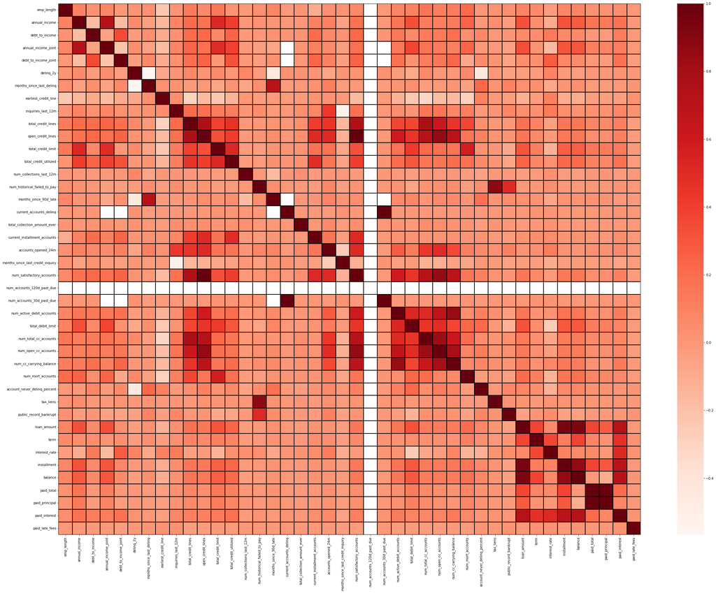

```python
fig = plt.figure(figsize = (40, 30))
data_ploting = loan_df.corr(method= 'pearson')
sns.heatmap(data_ploting, cmap='Reds', linecolor='black', linewidths= 2 )
plt.show()
```

Through this Matrix we can see that with a few exceptions, most of the columns have very little correlation

```python
pd.set_option('display.max_columns', None)
```

```python
#Check for Multicollinearity Using Spearman Correlations

loan_df.corr(method = "spearman").round(2)
```

|  | emp_length | annual_income | debt_to_income | annual_income_joint | debt_to_income_joint | delinq_2y | months_since_last_delinq | earliest_credit_line | inquiries_last_12m | total_credit_lines | open_credit_lines | total_credit_limit | total_credit_utilized | num_collections_last_12m | num_historical_failed_to_pay | months_since_90d_late | current_accounts_delinq | total_collection_amount_ever | current_installment_accounts | accounts_opened_24m | months_since_last_credit_inquiry | num_satisfactory_accounts | num_accounts_120d_past_due | num_accounts_30d_past_due | num_active_debit_accounts | total_debit_limit | num_total_cc_accounts | num_open_cc_accounts | num_cc_carrying_balance | … |
| --- | --- | --- | --- | --- | --- | --- | --- | --- | --- | --- | --- | --- | --- | --- | --- | --- | --- | --- | --- | --- | --- | --- | --- | --- | --- | --- | --- | --- | --- | --- |
| emp_length | 1.00 | 0.17 | 0.06 | 0.09 | 0.00 | 0.02 | 0.03 | -0.27 | -0.01 | 0.15 | 0.08 | 0.19 | 0.07 | -0.01 | 0.04 | 0.08 | -0.01 | -0.01 | -0.04 | 0.03 | 0.01 | 0.08 | NaN | -0.01 | 0.07 | 0.10 | 0.17 | 0.11 | 0.12 | … |
| annual_income | 0.17 | 1.00 | -0.20 | 0.67 | -0.15 | 0.08 | -0.05 | -0.22 | 0.13 | 0.33 | 0.28 | 0.53 | 0.47 | -0.00 | -0.01 | -0.01 | 0.01 | -0.03 | 0.25 | 0.14 | -0.07 | 0.28 | NaN | 0.01 | 0.22 | 0.39 | 0.22 | 0.18 | 0.18 | … |
| debt_to_income | 0.06 | -0.20 | 1.00 | -0.08 | 0.59 | -0.04 | 0.05 | -0.11 | 0.04 | 0.31 | 0.35 | 0.22 | 0.51 | -0.02 | -0.00 | 0.04 | 0.01 | -0.03 | 0.47 | 0.13 | 0.03 | 0.35 | NaN | 0.01 | 0.20 | 0.12 | 0.19 | 0.21 | 0.27 | … |
| annual_income_joint | 0.09 | 0.67 | -0.08 | 1.00 | -0.21 | 0.05 | -0.03 | -0.20 | 0.06 | 0.31 | 0.27 | 0.50 | 0.41 | -0.01 | -0.06 | -0.04 | NaN | -0.04 | 0.21 | 0.08 | -0.02 | 0.27 | NaN | NaN | 0.20 | 0.35 | 0.22 | 0.18 | 0.16 | … |
| debt_to_income_joint | 0.00 | -0.15 | 0.59 | -0.21 | 1.00 | -0.05 | 0.08 | -0.09 | 0.03 | 0.20 | 0.25 | 0.04 | 0.39 | 0.00 | -0.06 | 0.05 | NaN | -0.01 | 0.33 | 0.12 | -0.02 | 0.25 | NaN | NaN | 0.18 | 0.06 | 0.12 | 0.16 | 0.23 | … |
| delinq_2y | 0.02 | 0.08 | -0.04 | 0.05 | -0.05 | 1.00 | -0.80 | -0.10 | 0.01 | 0.08 | 0.03 | 0.06 | -0.01 | 0.09 | -0.06 | -0.51 | 0.03 | 0.03 | 0.01 | -0.05 | -0.00 | 0.02 | NaN | 0.03 | -0.02 | -0.10 | 0.07 | 0.01 | 0.00 | … |
| months_since_last_delinq | 0.03 | -0.05 | 0.05 | -0.03 | 0.08 | -0.80 | 1.00 | 0.03 | 0.03 | -0.01 | -0.00 | -0.06 | 0.04 | -0.06 | 0.08 | 0.70 | -0.03 | 0.04 | 0.03 | 0.13 | -0.03 | -0.00 | NaN | -0.03 | 0.01 | 0.06 | -0.03 | 0.00 | 0.01 | … |
| earliest_credit_line | -0.27 | -0.22 | -0.11 | -0.20 | -0.09 | -0.10 | 0.03 | 1.00 | 0.03 | -0.36 | -0.20 | -0.28 | -0.19 | -0.00 | -0.06 | -0.01 | -0.02 | 0.02 | -0.04 | 0.02 | -0.01 | -0.19 | NaN | -0.02 | -0.13 | -0.25 | -0.35 | -0.19 | -0.17 | … |
| inquiries_last_12m | -0.01 | 0.13 | 0.04 | 0.06 | 0.03 | 0.01 | 0.03 | 0.03 | 1.00 | 0.24 | 0.21 | 0.18 | 0.17 | 0.01 | 0.08 | -0.01 | -0.01 | 0.06 | 0.15 | 0.47 | -0.69 | 0.21 | NaN | -0.01 | 0.06 | 0.01 | 0.18 | 0.17 | 0.10 | … |
| total_credit_lines | 0.15 | 0.33 | 0.31 | 0.31 | 0.20 | 0.08 | -0.01 | -0.36 | 0.24 | 1.00 | 0.76 | 0.51 | 0.53 | 0.00 | 0.00 | 0.02 | -0.01 | 0.02 | 0.44 | 0.44 | -0.13 | 0.76 | NaN | -0.01 | 0.34 | 0.38 | 0.78 | 0.61 | 0.43 | … |
| open_credit_lines | 0.08 | 0.28 | 0.35 | 0.27 | 0.25 | 0.03 | -0.00 | -0.20 | 0.21 | 0.76 | 1.00 | 0.45 | 0.50 | -0.01 | 0.02 | 0.05 | -0.00 | 0.03 | 0.48 | 0.50 | -0.11 | 1.00 | NaN | -0.00 | 0.56 | 0.47 | 0.72 | 0.84 | 0.67 | … |
| total_credit_limit | 0.19 | 0.53 | 0.22 | 0.50 | 0.04 | 0.06 | -0.06 | -0.28 | 0.18 | 0.51 | 0.45 | 1.00 | 0.61 | -0.02 | -0.07 | 0.01 | 0.01 | -0.05 | 0.36 | 0.24 | -0.07 | 0.45 | NaN | 0.01 | 0.20 | 0.44 | 0.31 | 0.26 | 0.21 | … |
| total_credit_utilized | 0.07 | 0.47 | 0.51 | 0.41 | 0.39 | -0.01 | 0.04 | -0.19 | 0.17 | 0.53 | 0.50 | 0.61 | 1.00 | -0.03 | -0.04 | 0.05 | 0.01 | -0.05 | 0.67 | 0.24 | -0.05 | 0.50 | NaN | 0.01 | 0.25 | 0.35 | 0.24 | 0.23 | 0.27 | … |
| num_collections_last_12m | -0.01 | -0.00 | -0.02 | -0.01 | 0.00 | 0.09 | -0.06 | -0.00 | 0.01 | 0.00 | -0.01 | -0.02 | -0.03 | 1.00 | -0.01 | -0.16 | -0.00 | 0.18 | -0.01 | 0.00 | -0.01 | -0.01 | NaN | -0.00 | -0.00 | -0.03 | 0.01 | -0.01 | -0.01 | … |
| num_historical_failed_to_pay | 0.04 | -0.01 | -0.00 | -0.06 | -0.06 | -0.06 | 0.08 | -0.06 | 0.08 | 0.00 | 0.02 | -0.07 | -0.04 | -0.01 | 1.00 | 0.07 | -0.00 | 0.01 | -0.01 | 0.11 | -0.04 | 0.02 | NaN | -0.00 | 0.00 | -0.10 | 0.03 | 0.05 | 0.04 | … |
| months_since_90d_late | 0.08 | -0.01 | 0.04 | -0.04 | 0.05 | -0.51 | 0.70 | -0.01 | -0.01 | 0.02 | 0.05 | 0.01 | 0.05 | -0.16 | 0.07 | 1.00 | NaN | 0.06 | 0.03 | 0.10 | 0.01 | 0.05 | NaN | NaN | 0.06 | 0.10 | 0.01 | 0.06 | 0.05 | … |
| current_accounts_delinq | -0.01 | 0.01 | 0.01 | NaN | NaN | 0.03 | -0.03 | -0.02 | -0.01 | -0.01 | -0.00 | 0.01 | 0.01 | -0.00 | -0.00 | NaN | 1.00 | -0.00 | 0.01 | -0.01 | 0.02 | -0.01 | NaN | 1.00 | -0.01 | -0.00 | -0.00 | -0.01 | -0.00 | … |
| total_collection_amount_ever | -0.01 | -0.03 | -0.03 | -0.04 | -0.01 | 0.03 | 0.04 | 0.02 | 0.06 | 0.02 | 0.03 | -0.05 | -0.05 | 0.18 | 0.01 | 0.06 | -0.00 | 1.00 | 0.00 | 0.06 | -0.04 | 0.03 | NaN | -0.00 | -0.00 | -0.14 | 0.01 | 0.03 | 0.03 | … |
| current_installment_accounts | -0.04 | 0.25 | 0.47 | 0.21 | 0.33 | 0.01 | 0.03 | -0.04 | 0.15 | 0.44 | 0.48 | 0.36 | 0.67 | -0.01 | -0.01 | 0.03 | 0.01 | 0.00 | 1.00 | 0.24 | -0.04 | 0.48 | NaN | 0.01 | 0.05 | 0.07 | 0.06 | 0.05 | 0.06 | … |
| accounts_opened_24m | 0.03 | 0.14 | 0.13 | 0.08 | 0.12 | -0.05 | 0.13 | 0.02 | 0.47 | 0.44 | 0.50 | 0.24 | 0.24 | 0.00 | 0.11 | 0.10 | -0.01 | 0.06 | 0.24 | 1.00 | -0.24 | 0.50 | NaN | -0.01 | 0.25 | 0.13 | 0.41 | 0.47 | 0.34 | … |
| months_since_last_credit_inquiry | 0.01 | -0.07 | 0.03 | -0.02 | -0.02 | -0.00 | -0.03 | -0.01 | -0.69 | -0.13 | -0.11 | -0.07 | -0.05 | -0.01 | -0.04 | 0.01 | 0.02 | -0.04 | -0.04 | -0.24 | 1.00 | -0.11 | NaN | 0.02 | -0.03 | -0.01 | -0.11 | -0.10 | -0.05 | … |
| num_satisfactory_accounts | 0.08 | 0.28 | 0.35 | 0.27 | 0.25 | 0.02 | -0.00 | -0.19 | 0.21 | 0.76 | 1.00 | 0.45 | 0.50 | -0.01 | 0.02 | 0.05 | -0.01 | 0.03 | 0.48 | 0.50 | -0.11 | 1.00 | NaN | -0.01 | 0.56 | 0.47 | 0.71 | 0.84 | 0.67 | … |
| num_accounts_120d_past_due | NaN | NaN | NaN | NaN | NaN | NaN | NaN | NaN | NaN | NaN | NaN | NaN | NaN | NaN | NaN | NaN | NaN | NaN | NaN | NaN | NaN | NaN | NaN | NaN | NaN | NaN | NaN | NaN | NaN | … |
| num_accounts_30d_past_due | -0.01 | 0.01 | 0.01 | NaN | NaN | 0.03 | -0.03 | -0.02 | -0.01 | -0.01 | -0.00 | 0.01 | 0.01 | -0.00 | -0.00 | NaN | 1.00 | -0.00 | 0.01 | -0.01 | 0.02 | -0.01 | NaN | 1.00 | -0.01 | -0.00 | -0.00 | -0.01 | -0.00 | … |
| num_active_debit_accounts | 0.07 | 0.22 | 0.20 | 0.20 | 0.18 | -0.02 | 0.01 | -0.13 | 0.06 | 0.34 | 0.56 | 0.20 | 0.25 | -0.00 | 0.00 | 0.06 | -0.01 | -0.00 | 0.05 | 0.25 | -0.03 | 0.56 | NaN | -0.01 | 1.00 | 0.55 | 0.48 | 0.66 | 0.83 | … |
| total_debit_limit | 0.10 | 0.39 | 0.12 | 0.35 | 0.06 | -0.10 | 0.06 | -0.25 | 0.01 | 0.38 | 0.47 | 0.44 | 0.35 | -0.03 | -0.10 | 0.10 | -0.00 | -0.14 | 0.07 | 0.13 | -0.01 | 0.47 | NaN | -0.00 | 0.55 | 1.00 | 0.45 | 0.51 | 0.39 | … |
| num_total_cc_accounts | 0.17 | 0.22 | 0.19 | 0.22 | 0.12 | 0.07 | -0.03 | -0.35 | 0.18 | 0.78 | 0.72 | 0.31 | 0.24 | 0.01 | 0.03 | 0.01 | -0.00 | 0.01 | 0.06 | 0.41 | -0.11 | 0.71 | NaN | -0.00 | 0.48 | 0.45 | 1.00 | 0.82 | 0.60 | … |
| num_open_cc_accounts | 0.11 | 0.18 | 0.21 | 0.18 | 0.16 | 0.01 | 0.00 | -0.19 | 0.17 | 0.61 | 0.84 | 0.26 | 0.23 | -0.01 | 0.05 | 0.06 | -0.01 | 0.03 | 0.05 | 0.47 | -0.10 | 0.84 | NaN | -0.01 | 0.66 | 0.51 | 0.82 | 1.00 | 0.79 | … |
| num_cc_carrying_balance | 0.12 | 0.18 | 0.27 | 0.16 | 0.23 | 0.00 | 0.01 | -0.17 | 0.10 | 0.43 | 0.67 | 0.21 | 0.27 | -0.01 | 0.04 | 0.05 | -0.00 | 0.03 | 0.06 | 0.34 | -0.05 | 0.67 | NaN | -0.00 | 0.83 | 0.39 | 0.60 | 0.79 | 1.00 | … |
| num_mort_accounts | 0.23 | 0.34 | 0.05 | 0.30 | -0.05 | 0.09 | -0.05 | -0.34 | 0.15 | 0.39 | 0.20 | 0.70 | 0.26 | -0.02 | -0.03 | 0.02 | 0.01 | -0.03 | 0.09 | 0.13 | -0.07 | 0.20 | NaN | 0.01 | 0.04 | 0.23 | 0.24 | 0.12 | 0.08 | … |
| account_never_delinq_percent | -0.03 | -0.06 | 0.06 | -0.08 | 0.03 | -0.47 | 0.23 | 0.15 | -0.06 | -0.08 | 0.01 | -0.02 | 0.03 | -0.07 | 0.07 | 0.17 | -0.02 | -0.14 | -0.03 | -0.00 | 0.03 | 0.01 | NaN | -0.02 | 0.06 | 0.23 | -0.05 | 0.04 | 0.02 | … |
| tax_liens | 0.03 | 0.06 | -0.03 | 0.01 | 0.02 | 0.01 | 0.01 | -0.04 | 0.01 | -0.02 | -0.00 | -0.01 | 0.01 | 0.01 | 0.41 | 0.03 | -0.00 | 0.03 | -0.02 | 0.02 | -0.01 | -0.00 | NaN | -0.00 | 0.03 | 0.00 | -0.02 | 0.01 | 0.02 | … |
| public_record_bankrupt | 0.03 | -0.03 | 0.01 | -0.07 | -0.06 | -0.07 | 0.09 | -0.04 | 0.09 | 0.01 | 0.02 | -0.08 | -0.05 | -0.02 | 0.91 | 0.06 | -0.00 | 0.00 | -0.00 | 0.11 | -0.04 | 0.02 | NaN | -0.00 | -0.01 | -0.11 | 0.04 | 0.05 | 0.03 | … |
| loan_amount | 0.09 | 0.42 | 0.06 | 0.36 | 0.06 | -0.03 | 0.03 | -0.13 | 0.04 | 0.20 | 0.17 | 0.32 | 0.31 | -0.03 | -0.03 | 0.03 | 0.00 | -0.07 | 0.07 | 0.02 | -0.03 | 0.17 | NaN | 0.00 | 0.17 | 0.35 | 0.17 | 0.16 | 0.14 | … |
| term | 0.06 | 0.10 | 0.05 | 0.05 | 0.05 | -0.02 | 0.04 | -0.05 | 0.04 | 0.10 | 0.07 | 0.14 | 0.13 | -0.02 | -0.00 | 0.01 | 0.02 | -0.01 | 0.08 | 0.03 | -0.03 | 0.07 | NaN | 0.02 | 0.02 | 0.07 | 0.04 | 0.04 | 0.02 | … |
| interest_rate | -0.04 | -0.14 | 0.21 | -0.18 | 0.29 | 0.11 | -0.10 | 0.12 | 0.15 | -0.07 | -0.02 | -0.16 | 0.05 | 0.03 | 0.06 | -0.09 | 0.01 | 0.11 | 0.06 | 0.12 | -0.11 | -0.02 | NaN | 0.01 | 0.03 | -0.31 | -0.08 | -0.04 | 0.09 | … |
| installment | 0.08 | 0.40 | 0.07 | 0.33 | 0.08 | -0.01 | 0.01 | -0.11 | 0.05 | 0.18 | 0.17 | 0.28 | 0.30 | -0.02 | -0.02 | 0.02 | 0.00 | -0.05 | 0.06 | 0.03 | -0.04 | 0.17 | NaN | 0.00 | 0.19 | 0.32 | 0.16 | 0.16 | 0.16 | … |
| balance | 0.09 | 0.37 | 0.07 | 0.33 | 0.07 | -0.03 | 0.04 | -0.12 | 0.02 | 0.17 | 0.16 | 0.28 | 0.28 | -0.03 | -0.02 | 0.01 | 0.01 | -0.06 | 0.07 | 0.00 | -0.03 | 0.16 | NaN | 0.01 | 0.17 | 0.31 | 0.15 | 0.14 | 0.14 | … |
| paid_total | 0.06 | 0.34 | 0.04 | 0.30 | 0.05 | -0.01 | 0.01 | -0.10 | 0.04 | 0.16 | 0.14 | 0.24 | 0.25 | -0.03 | -0.01 | 0.02 | 0.01 | -0.04 | 0.05 | 0.03 | -0.03 | 0.14 | NaN | 0.01 | 0.14 | 0.27 | 0.14 | 0.13 | 0.11 | … |
| paid_principal | 0.06 | 0.34 | -0.01 | 0.31 | -0.03 | -0.03 | 0.02 | -0.10 | 0.01 | 0.15 | 0.13 | 0.24 | 0.21 | -0.03 | -0.02 | 0.03 | 0.00 | -0.05 | 0.03 | 0.00 | -0.00 | 0.13 | NaN | 0.00 | 0.12 | 0.31 | 0.15 | 0.13 | 0.09 | … |
| paid_interest | 0.06 | 0.27 | 0.15 | 0.18 | 0.18 | 0.02 | -0.01 | -0.06 | 0.08 | 0.13 | 0.13 | 0.18 | 0.26 | -0.02 | 0.02 | -0.02 | 0.01 | -0.00 | 0.09 | 0.06 | -0.06 | 0.13 | NaN | 0.01 | 0.16 | 0.14 | 0.10 | 0.11 | 0.16 | … |
| paid_late_fees | 0.00 | -0.02 | -0.01 | -0.01 | -0.04 | -0.00 | 0.01 | 0.02 | 0.00 | -0.03 | -0.03 | -0.02 | -0.02 | -0.01 | 0.00 | -0.01 | -0.00 | -0.01 | -0.01 | -0.01 | -0.02 | -0.03 | NaN | -0.00 | -0.03 | -0.03 | -0.03 | -0.03 | -0.02 | … |

In this matrix, we can see the correlation values of each attribute.

### Visualizing categorical data with interest rate

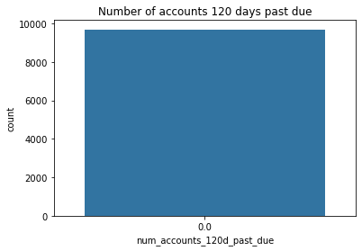

```python
fig = plt.figure(figsize = (6,4))
sns.countplot(loan_df['num_accounts_120d_past_due'])
plt.title('Number of accounts 120 days past due')
plt.show()
```

```python
loan_df.num_accounts_120d_past_due.unique()
```

```
array([ 0., nan])
```

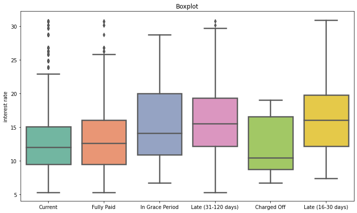

```python
plt.figure(figsize=(10,6), tight_layout=True)

ax = sns.boxplot(data=loan_df, x='loan_status', y='interest_rate', palette='Set2', linewidth=2.5)
ax.set(title='Boxplot', xlabel='', ylabel='interest rate')

plt.show()
```

The median interest rate is more for people who have not paid their interest with the exception of those who are charged off. This might be because the number of rows we have are not sufficient.

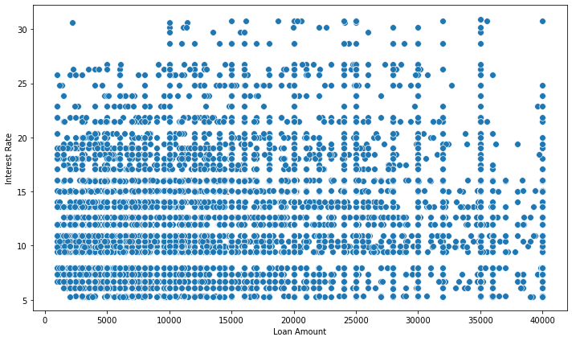

```python
plt.figure(figsize=(10,6), tight_layout=True)
ax = sns.scatterplot(data=loan_df, x='loan_amount', y='interest_rate', palette='Set2', s=60)
ax.set(xlabel='Loan Amount', ylabel='Interest Rate')
plt.show()
```

There seems to be no pattern in interest rate vs loan amount

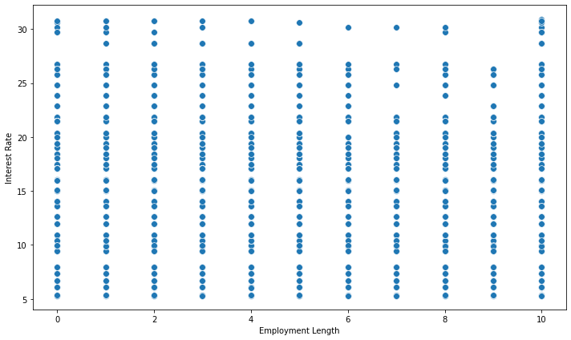

```python
plt.figure(figsize=(10,6), tight_layout=True)
ax = sns.scatterplot(data=loan_df, x='emp_length', y='interest_rate', palette='Set2', s=60)
ax.set(xlabel='Employment Length', ylabel='Interest Rate')
plt.show()
```

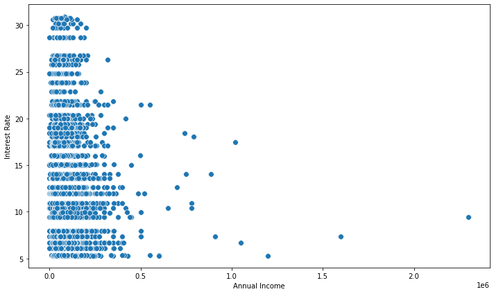

```python
plt.figure(figsize=(10,6), tight_layout=True)
ax = sns.scatterplot(data=loan_df, x='annual_income', y='interest_rate', palette='Set2', s=60)
ax.set(xlabel='Annual Income', ylabel='Interest Rate')
plt.show()
```

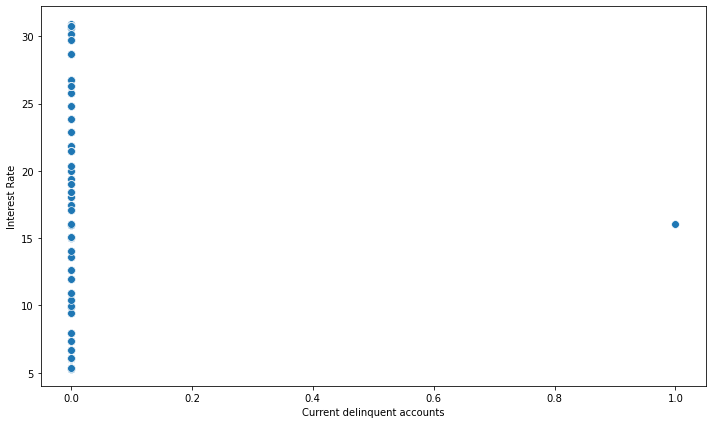

```python
plt.figure(figsize=(10,6), tight_layout=True)
ax = sns.scatterplot(data=loan_df, x='current_accounts_delinq', y='interest_rate', palette='Set2', s=60)
ax.set(xlabel='Current delinquent accounts', ylabel='Interest Rate')
plt.show()
```

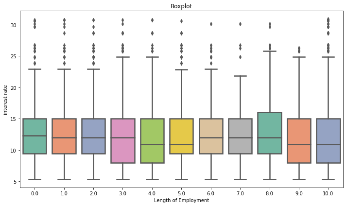

```python
plt.figure(figsize=(10,6), tight_layout=True)

ax = sns.boxplot(data=loan_df, x='emp_length', y='interest_rate', palette='Set2', linewidth=2.5)
ax.set(title='Boxplot', xlabel='Length of Employment', ylabel='interest rate')

plt.show()
```

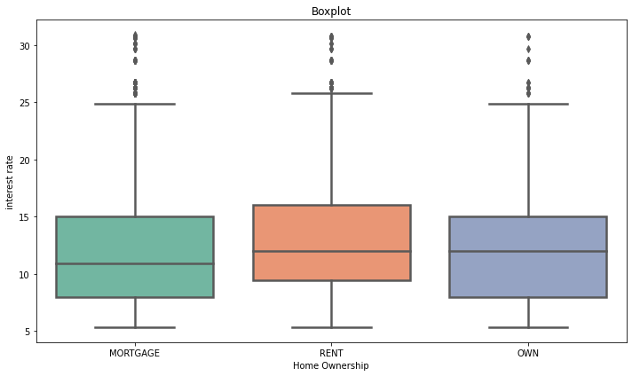

```python
plt.figure(figsize=(10,6), tight_layout=True)

ax = sns.boxplot(data=loan_df, x='homeownership', y='interest_rate', palette='Set2', linewidth=2.5)
ax.set(title='Boxplot', xlabel='Home Ownership', ylabel='interest rate')

plt.show()
```

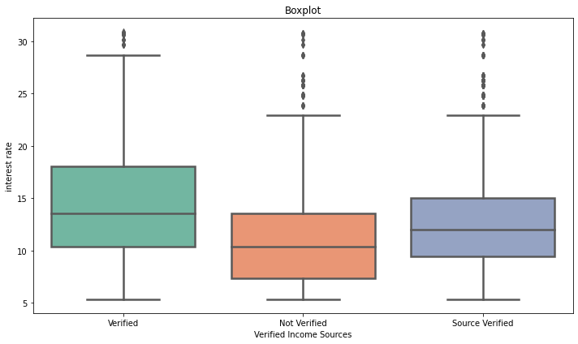

```python
plt.figure(figsize=(10,6), tight_layout=True)

ax = sns.boxplot(data=loan_df, x='verified_income', y='interest_rate', palette='Set2', linewidth=2.5)
ax.set(title='Boxplot', xlabel='Verified Income Sources', ylabel='interest rate')

plt.show()
```

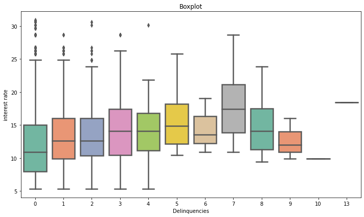

```python
plt.figure(figsize=(10,6), tight_layout=True)

ax = sns.boxplot(data=loan_df, x='delinq_2y', y='interest_rate', palette='Set2', linewidth=2.5)
ax.set(title='Boxplot', xlabel='Delinquencies', ylabel='interest rate')

plt.show()
```

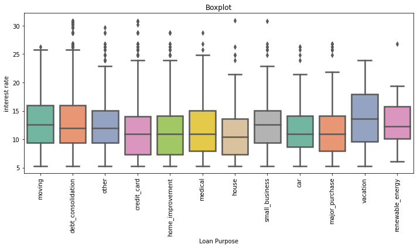

```python
plt.figure(figsize=(10,6), tight_layout=True)

ax = sns.boxplot(data=loan_df, x='loan_purpose', y='interest_rate', palette='Set2', linewidth=2.5)
ax.set(title='Boxplot', xlabel='Loan Purpose', ylabel='interest rate')
plt.xticks(rotation=90)

plt.show()
```

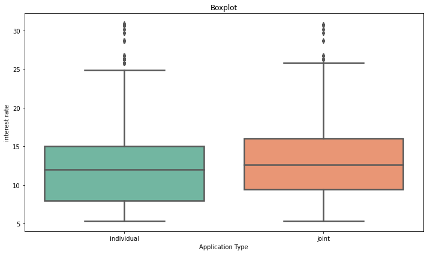

```python
plt.figure(figsize=(10,6), tight_layout=True)

ax = sns.boxplot(data=loan_df, x='application_type', y='interest_rate', palette='Set2', linewidth=2.5)
ax.set(title='Boxplot', xlabel='Application Type', ylabel='interest rate')

plt.show()
```

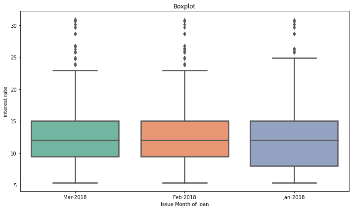

```python
plt.figure(figsize=(10,6), tight_layout=True)

ax = sns.boxplot(data=loan_df, x='issue_month', y='interest_rate', palette='Set2', linewidth=2.5)
ax.set(title='Boxplot', xlabel='Issue Month of loan', ylabel='interest rate')

plt.show()
```

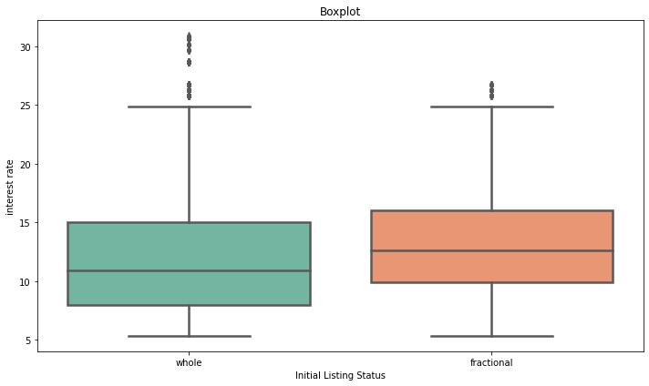

```python
plt.figure(figsize=(10,6), tight_layout=True)

ax = sns.boxplot(data=loan_df, x='initial_listing_status', y='interest_rate', palette='Set2', linewidth=2.5)
ax.set(title='Boxplot', xlabel='Initial Listing Status', ylabel='interest rate')

plt.show()
```

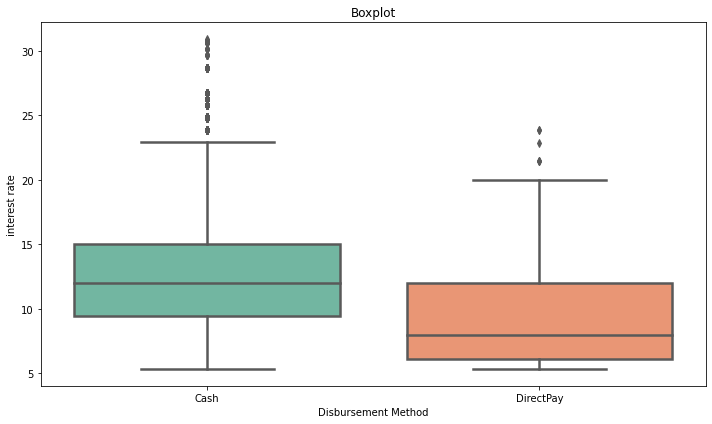

```python
plt.figure(figsize=(10,6), tight_layout=True)

ax = sns.boxplot(data=loan_df, x='disbursement_method', y='interest_rate', palette='Set2', linewidth=2.5)
ax.set(title='Boxplot', xlabel='Disbursement Method', ylabel='interest rate')

plt.show()
```

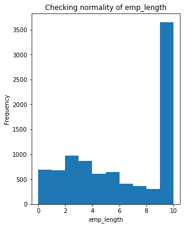

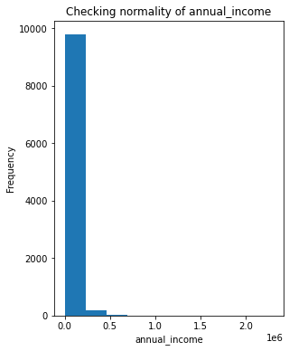

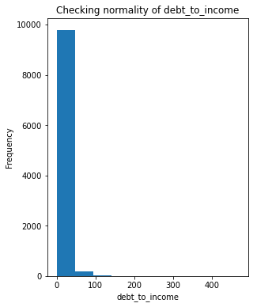

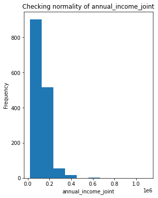

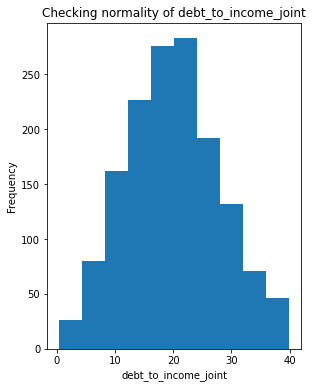

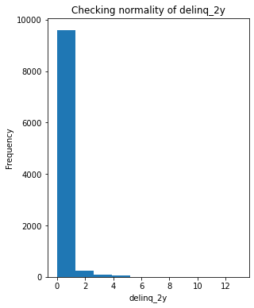

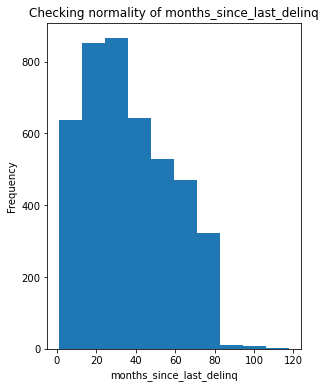

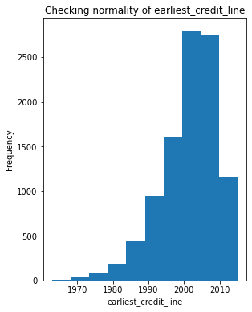

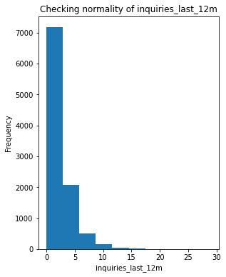

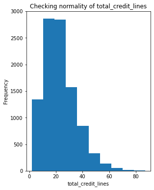

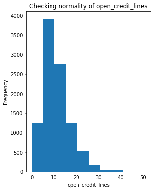

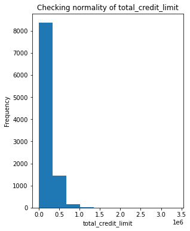

[30 more figures not shown]

```python
for column in loan_df.loc[:, ~loan_df.columns.isin(['emp_title', 'state', 'homeownership','verified_income',
                                                         'verification_income_joint','loan_purpose','application_type',
                                                         'grade', 'sub_grade', 'issue_month', 'loan_status',
                                                         'initial_listing_status','disbursement_method'])]:
    fig = plt.figure(figsize=(10, 6))
    ax1 = fig.add_subplot(121)
    ax1.set_xlabel("{}".format(column))
    ax1.set_ylabel('Frequency')
    ax1.set_title("Checking normality of {}".format(column))
    loan_df[column].plot(kind="hist")
```

Looking at these plots, scaling is necessary